# Lab1- Group A 13

Arash Haratian

2022-11-15

## Attaching Packages

```r
library(tidyverse)
library(kknn)
```

## Assignment 1

### 1) Importing And Spliting The Data

First we read the data and split it to three parts (training, validation and test sets) using the code from the lecture slides:

```r
optdigits <- read.csv("./dataset/optdigits.csv", header = FALSE)

optdigits <- optdigits %>%
  mutate(y = as.factor(V65)) %>%
  select(!V65)

n <- nrow(optdigits)
set.seed(12345)
train_idx <- sample(seq_len(n), floor(n * 0.5))
train_data <- optdigits[train_idx, ]

remainder_idx <- setdiff(seq_len(n), train_idx)

set.seed(12345)
valid_idx <- sample(remainder_idx, floor(n * 0.25))
valid_data <- optdigits[valid_idx, ]

test_idx <- setdiff(remainder_idx, valid_idx)
test_data <- optdigits[test_idx, ]
```

### 2) Training the 30-NN

```r
knn_model_train <- kknn(y~., train = train_data, test = train_data, k = 30, kernel = "rectangular")
g_hat_train <-knn_model_train$fitted.values
cm_train <- table(train_data$y, g_hat_train)
knitr::kable(cm_train, caption = "Confusion matrix for 30-nn on train dataset")
```

Confusion matrix for 30-nn on train dataset

|  | 0 | 1 | 2 | 3 | 4 | 5 | 6 | 7 | 8 | 9 |
| --- | --- | --- | --- | --- | --- | --- | --- | --- | --- | --- |
| 0 | 202 | 0 | 0 | 0 | 0 | 0 | 0 | 0 | 0 | 0 |
| 1 | 0 | 179 | 11 | 0 | 0 | 0 | 0 | 1 | 1 | 3 |
| 2 | 0 | 1 | 190 | 0 | 0 | 0 | 0 | 1 | 0 | 0 |
| 3 | 0 | 0 | 0 | 185 | 0 | 1 | 0 | 1 | 0 | 1 |
| 4 | 1 | 3 | 0 | 0 | 159 | 0 | 0 | 7 | 1 | 4 |
| 5 | 0 | 0 | 0 | 1 | 0 | 171 | 0 | 1 | 0 | 8 |
| 6 | 0 | 2 | 0 | 0 | 0 | 0 | 190 | 0 | 0 | 0 |
| 7 | 0 | 3 | 0 | 0 | 0 | 0 | 0 | 178 | 1 | 0 |
| 8 | 0 | 10 | 0 | 2 | 0 | 0 | 2 | 0 | 188 | 2 |
| 9 | 1 | 3 | 0 | 5 | 2 | 0 | 0 | 3 | 3 | 183 |

```r
error_train <- 1 - (sum(diag(cm_train)) / length(g_hat_train))
```

```r
knn_model_test <- kknn(y~., train = train_data, test = test_data, k = 30, kernel = "rectangular")
g_hat_test <- knn_model_test$fitted.values
cm_test <- table(test_data$y, g_hat_test)
knitr::kable(cm_test, caption = "Confusion matrix for 30-nn on test dataset")
```

Confusion matrix for 30-nn on test dataset

|  | 0 | 1 | 2 | 3 | 4 | 5 | 6 | 7 | 8 | 9 |
| --- | --- | --- | --- | --- | --- | --- | --- | --- | --- | --- |
| 0 | 77 | 0 | 0 | 0 | 1 | 0 | 0 | 0 | 0 | 0 |
| 1 | 0 | 81 | 2 | 0 | 0 | 0 | 0 | 0 | 0 | 3 |
| 2 | 0 | 0 | 98 | 0 | 0 | 0 | 0 | 0 | 3 | 0 |
| 3 | 0 | 0 | 0 | 107 | 0 | 2 | 0 | 0 | 1 | 1 |
| 4 | 0 | 0 | 0 | 0 | 94 | 0 | 2 | 6 | 2 | 5 |
| 5 | 0 | 1 | 1 | 0 | 0 | 93 | 2 | 1 | 0 | 5 |
| 6 | 0 | 0 | 0 | 0 | 0 | 0 | 90 | 0 | 0 | 0 |
| 7 | 0 | 0 | 0 | 1 | 0 | 0 | 0 | 111 | 0 | 0 |
| 8 | 0 | 7 | 0 | 1 | 0 | 0 | 0 | 0 | 70 | 0 |
| 9 | 0 | 1 | 1 | 1 | 0 | 0 | 0 | 1 | 0 | 85 |

```r
error_test <- 1 - (sum(diag(cm_test)) / length(g_hat_test))
```

As it is evidenced in the confusion matrix for train dataset, 17 observations with label `9` misclassified. Also classes `1`, `4`, and `8`, each has 16 observations that are misclassified. For instance, 10 of the observations from class `8` has classified as class `1`.

On the other hand, class `4` has the most number of misclassifications (15 in overall). Moreover, Classes `5` and `8` have the most number of misclassifications after class `4` (10 and 8 respectively).

Only one `0` is misclassified in test data while there is no misclassification for class `0` in train dataset.

### 3) Plotting 5 Different Observations

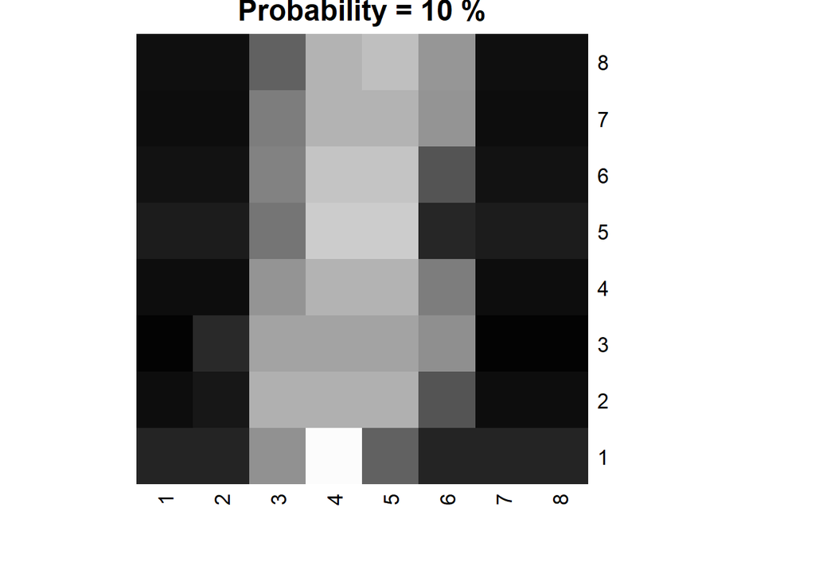

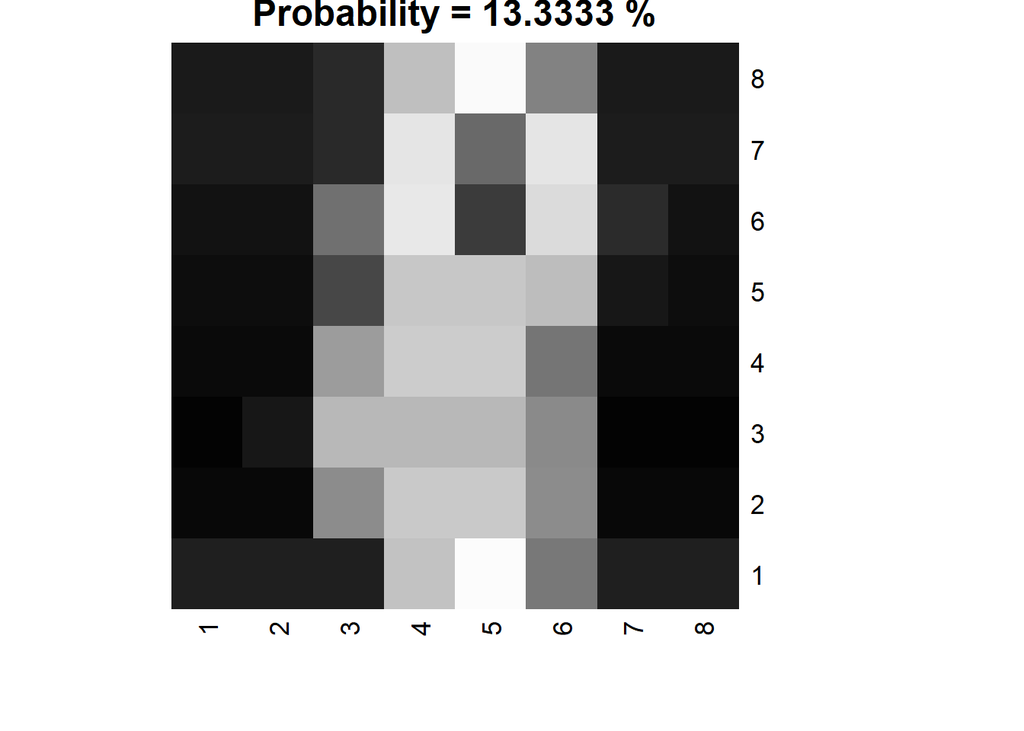

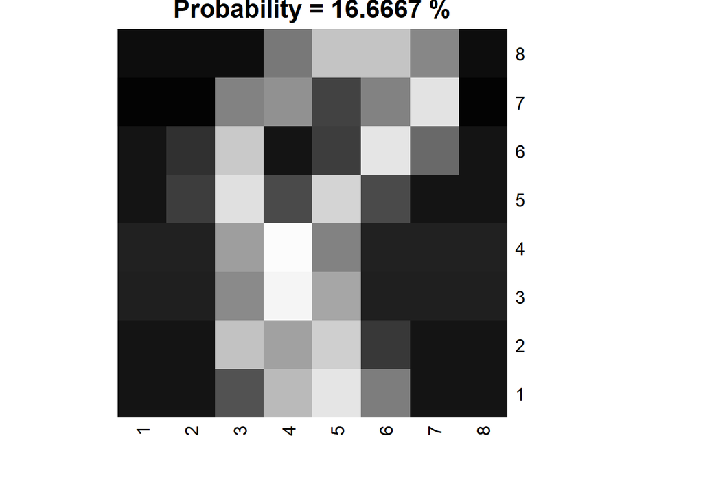

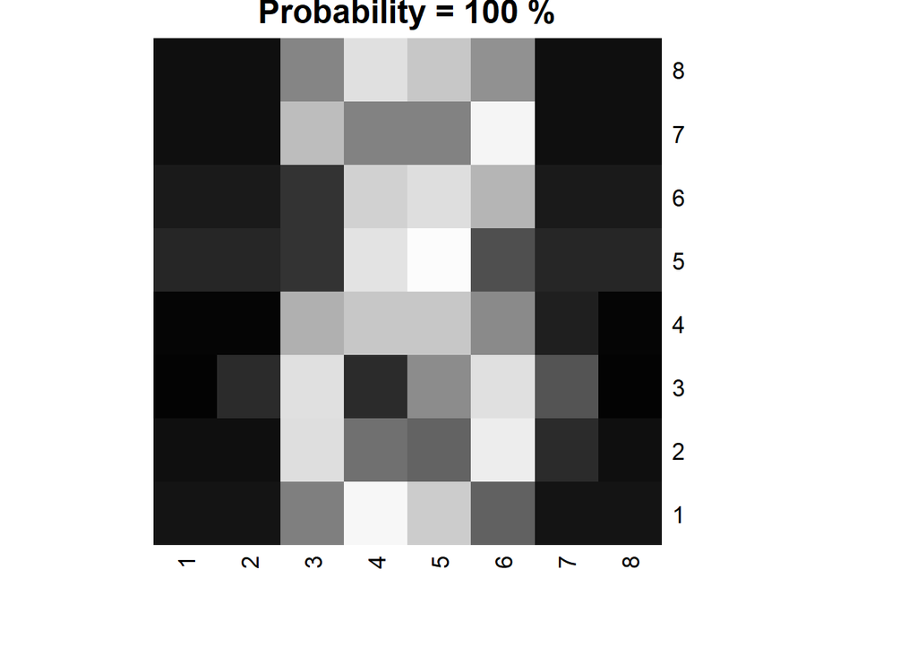

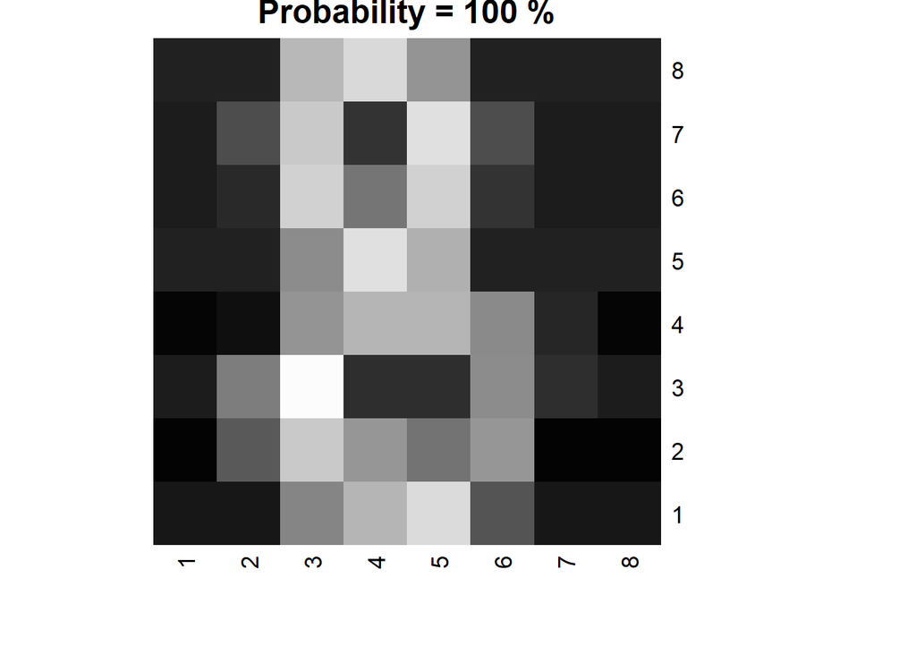

```r
prob_g8 <- predict(knn_model_train, type = "prob")
prob_g8 <- prob_g8[, "8"]
observations <- train_data %>%
  mutate("prob" = prob_g8) %>%
  filter(y == "8") %>%
  arrange(prob) %>%
  slice(
    c(1:3, length(y) - 1 , length(y))
  )

for(i in 1:5){
  fig_matrix <- matrix(as.numeric(observations[i, 1:64]), nrow = 8, byrow = T)
  fig_title <- paste("Probability =", round(observations[i, "prob"]* 100, 4), "%")
  heatmap(fig_matrix, Colv = NA, Rowv = NA, col = paste0("gray", 1:99), main = fig_title)
}
```

The last two plots are clearly resemble number 8, but the first three plots are barely similar to an 8. These first two plots are hard to classify visually since the top and the bottom circles of the 8 figure are blurred out.

### 4) Best Value of K

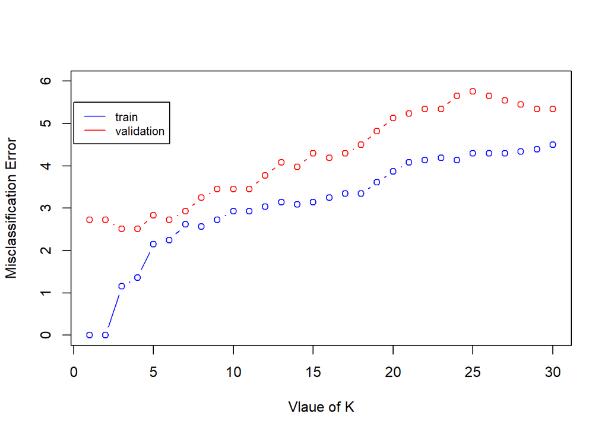

```r
results <- map(1:30, ~{
  model <- kknn(y~., train = train_data, test = train_data, k = .x, kernel = "rectangular")
  train_sum <- sum(diag(table(train_data$y, model$fitted.values)))
  model <- kknn(y~., train = train_data, test = valid_data, k = .x, kernel = "rectangular")
  valid_sum <- sum(diag(table(valid_data$y, model$fitted.values)))
  c(train_sum, valid_sum)
})
results <- as.data.frame(results)
names(results) <- 1:30

lengths <- c(nrow(train_data), nrow(valid_data))
errors <- (lengths - results) /lengths * 100

plot(t(errors)[, 1], type = "b", col = "blue",
     ylim = c(0, 6),
     xlab = "Vlaue of K",
     ylab = "Misclassification Error")
points(t(errors)[, 2], type = "b", col = "red")
legend(0, 5.5, legend=c("train", "validation"),
       col=c("blue", "red"), lty=1, cex=0.8)
```

By decreasing the value of `k`, the model predicts the train dataset more accurately than validation dataset (due to overfitting), while the error rate of the validation data first decrease but then it increases slightly (around `k = 3` to `k = 1`).

The best value of hyperparameter `k` is 3.

```r
best_k <- which.min(t(errors)[,2])
knn_model_test <- kknn(y~., train = train_data, test = test_data, k = best_k, kernel = "rectangular")
g_hat_test <- knn_model_test$fitted.values
cm_test <- table(test_data$y, g_hat_test)
knitr::kable(cm_test, caption = "Confusion matrix for 30-nn on test dataset")
```

|  | 0 | 1 | 2 | 3 | 4 | 5 | 6 | 7 | 8 | 9 |
| --- | --- | --- | --- | --- | --- | --- | --- | --- | --- | --- |
| 0 | 77 | 0 | 0 | 0 | 1 | 0 | 0 | 0 | 0 | 0 |
| 1 | 0 | 84 | 1 | 0 | 0 | 0 | 0 | 0 | 0 | 1 |
| 2 | 0 | 1 | 100 | 0 | 0 | 0 | 0 | 0 | 0 | 0 |
| 3 | 0 | 0 | 0 | 109 | 0 | 1 | 0 | 0 | 1 | 0 |
| 4 | 0 | 0 | 0 | 0 | 103 | 0 | 1 | 2 | 0 | 3 |
| 5 | 0 | 0 | 1 | 0 | 0 | 100 | 0 | 0 | 0 | 2 |
| 6 | 0 | 0 | 0 | 0 | 0 | 0 | 90 | 0 | 0 | 0 |
| 7 | 0 | 0 | 0 | 1 | 0 | 0 | 0 | 111 | 0 | 0 |
| 8 | 0 | 4 | 0 | 0 | 0 | 0 | 0 | 0 | 74 | 0 |
| 9 | 0 | 0 | 0 | 0 | 0 | 3 | 0 | 0 | 0 | 86 |

```r
error_test <- 1 - (sum(diag(cm_test)) / length(g_hat_test))
```

The misclassification error for test dataset is 2.4033% while for validation and train dataset is 2.513089% and 1.1512297% respectively. The error for the test dataset is colse to the one for the validation dataset which is a good sign (it means that model will have predict new data points with high accuracy as well). However, misclassification error for train dataset is smaller which means that the model has overfitted on the train dataset.

### 5) Best Value of K and Cross Entropy

First we define the cross entropy as a function in R:

```r
cross_entropy <- function(y, prob){
  one_hot <- model.matrix(~ 0 + y)
  result <- sum(- one_hot * log(prob +  1e-15))
  return(result / length(y))
}
```

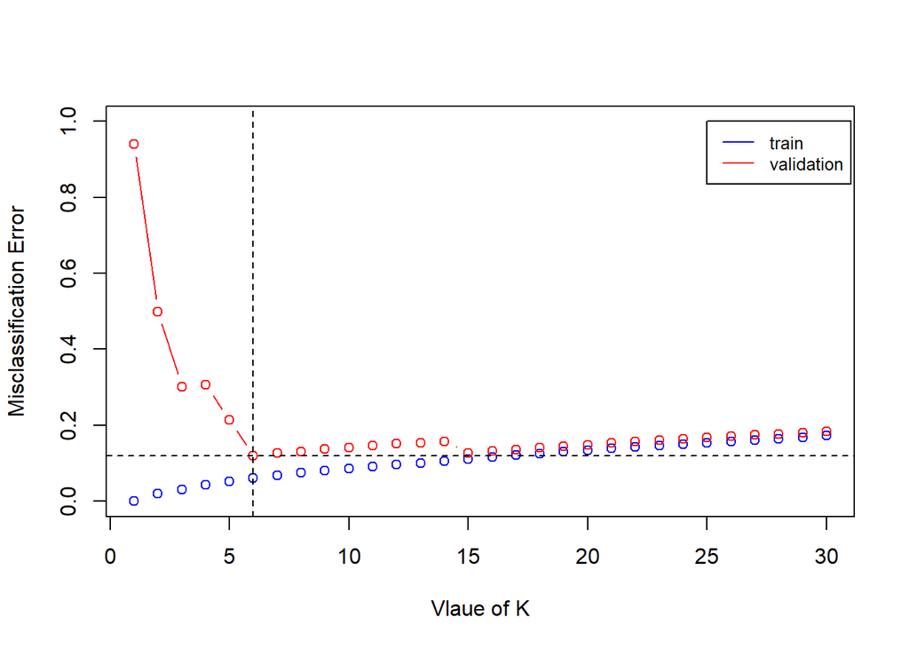

```r
results <- map(1:30, ~{
  model <- kknn(y~., train = train_data, test = train_data, k = .x, kernel = "rectangular")
  ce_train <- cross_entropy(train_data$y, model$prob)
  model <- kknn(y~., train = train_data, test = valid_data, k = .x, kernel = "rectangular")
  ce_valid <- cross_entropy(valid_data$y, model$prob)
  c(ce_train, ce_valid)
})
results <- as.data.frame(results)
names(results) <- 1:30

best_k <- which.min(t(results)[, 2])
ce_lowest <- t(results)[best_k, 2]

plot(t(results)[, 1], type = "b", col = "blue",
     ylim = c(0, 1),
     xlab = "Vlaue of K",
     ylab = "Misclassification Error")
points(t(results)[, 2], type = "b", col = "red")
abline(v = 6, h = ce_lowest, lty = 2)
legend(25, 1, legend=c("train", "validation"),
       col=c("blue", "red"), lty=1, cex=0.8)
```

The best value of k is 6 if we use cross-entropy as computing the error for validation dataset. The reason that cross entropy is more useful for datasets with multinomial distribution for the response is that we use probabilities (instead of final labels) to study the quality of the model.

## Assignment 2

### 1

```r
parkinsons <- read.csv("./dataset/parkinsons.csv")

parkinsons <- parkinsons %>% select(starts_with(c("Jitter", "Shimmer")), "NHR", "HNR", "RPDE", "DFA", "PPE", "motor_UPDRS")

n <- nrow(parkinsons)
set.seed(12345)
id <- sample(1:n, floor(n*0.6))
train <- parkinsons[id, ]
test <- parkinsons[-id, ]

scale_model <- caret::preProcess(train)
train <- predict(scale_model, train)
test <- predict(scale_model, test)
```

### 2

```r
lm_model <- lm(motor_UPDRS~. -1, train)
summary(lm_model)
```

```
##
## Call:
## lm(formula = motor_UPDRS ~ . - 1, data = train)
##
## Residuals:
##     Min      1Q  Median      3Q     Max
## -3.0255 -0.7363 -0.1087  0.7333  2.1960
##
## Coefficients:
##                 Estimate Std. Error t value Pr(>|t|)
## Jitter...       0.186931   0.149561   1.250 0.211431
## Jitter.Abs.    -0.169609   0.040805  -4.157 3.31e-05 ***
## Jitter.RAP     -5.269544  18.834160  -0.280 0.779658
## Jitter.PPQ5    -0.074568   0.087766  -0.850 0.395592
## Jitter.DDP      5.249558  18.837525   0.279 0.780510
## Shimmer         0.592436   0.205981   2.876 0.004050 **
## Shimmer.dB.    -0.172655   0.139316  -1.239 0.215315
## Shimmer.APQ3   32.070932  77.159242   0.416 0.677694
## Shimmer.APQ5   -0.387507   0.113789  -3.405 0.000668 ***
## Shimmer.APQ11   0.305546   0.061236   4.990 6.34e-07 ***
## Shimmer.DDA   -32.387241  77.158814  -0.420 0.674695
## NHR            -0.185387   0.045567  -4.068 4.84e-05 ***
## HNR            -0.238543   0.036395  -6.554 6.41e-11 ***
## RPDE            0.004068   0.022664   0.179 0.857556
## DFA            -0.280318   0.020136 -13.921  < 2e-16 ***
## PPE             0.226467   0.032881   6.887 6.70e-12 ***
## ---
## Signif. codes:  0 '***' 0.001 '**' 0.01 '*' 0.05 '.' 0.1 ' ' 1
##
## Residual standard error: 0.9394 on 3509 degrees of freedom
## Multiple R-squared:  0.1212, Adjusted R-squared:  0.1172
## F-statistic: 30.25 on 16 and 3509 DF,  p-value: < 2.2e-16
```

```r
y_hat <- lm_model$fitted.values
mse <- sum((train$motor_UPDRS - y_hat)^2)/ nrow(train)
y_hat <- predict(lm_model, test)
mse <- sum((test$motor_UPDRS - y_hat)^2)/ nrow(test)
```

### 3

```r
log_likelihood <- function(params, data) {
  n <- nrow(data)
  theta <- matrix(params[1:16], ncol = 1)
  sigma <- params[17]
  x <- as.matrix(data[-17])
  y <- data[17]
  temp <- sum(((x %*% theta) - y)^2)
  result <- -((n/2) * log(2* pi * sigma^2)) - ( (1/(2*sigma^2)) * as.vector(temp))
  return(-result)
}
# optim(c(rep(0, 16), 1), method = "BFGS", log_likelihood, data = train)
# coef(lm_model) %>% round(5)
```

```r
ridge_likelihood <- function(params, lambda, data){
  n <- nrow(data)
  theta <- matrix(params[1:16], ncol = 1)
  sigma <- params <- params[17]
  x <- data[-17]
  y <- data[17]
  temp <- sum(((as.matrix(x) %*% theta) - y)^2)
  result <- -((n/2) * log(2* pi * sigma^2)) - ( (1/(2*sigma^2)) * as.vector(temp)) - lambda * sum(theta^2)
  return(-result)
}
# ridge_likelihood(rep(0, 21), 10, 10, train)
# ridge_likelihood(coef(lm_model), 10, 10, train)
```

```r
ridge_opt <- function(lambda, data){
  init_points <- c(rep(0, 16), 1)
  optim(init_points, ridge_likelihood, method = "BFGS", data = data, lambda = lambda)
}
# ridge_opt(10, train)
# MASS::lm.ridge(motor_UPDRS~. -1, train, lambda = 10) %>% coef() %>% round(digits = 5)
```

```r
df_ridge <- function(lambda, data){
  x <- as.matrix(data[-17])
  y <- data[17]
  hat_matrix <- x %*% solve(t(x) %*% x + diag(lambda, ncol(x))) %*% t(x)
  return(sum(diag(hat_matrix)))
}

# df_ridge(10, train)
# df_ridge(1, train)
```

### 4

```r
theta_1 <- (ridge_opt(1, train))$par
theta_100 <- (ridge_opt(100, train))$par
theta_1000 <- (ridge_opt(1000, train))$par

y_hat_1 <- theta_1[1:16] %*% t(as.matrix(train[-17]))
sum((y_hat_1 - train[17]) ^ 2) / nrow(train)
```

```
## [1] 0.8786271
```

```r
y_hat_100 <- theta_100[1:16] %*% t(as.matrix(train[-17]))
sum((y_hat_100 - train[17]) ^ 2) / nrow(train)
```

```
## [1] 0.8844104
```

```r
y_hat_1000 <- theta_1000[1:16] %*% t(as.matrix(train[-17]))
sum((y_hat_1000 - train[17]) ^ 2) / nrow(train)
```

```
## [1] 0.9211216
```

```r
print("test:")
```

```
## [1] "test:"
```

```r
y_hat_1 <- theta_1[1:16] %*% t(as.matrix(test[-17]))
sum((y_hat_1 - test[17]) ^ 2) / nrow(test)
```

```
## [1] 0.9349969
```

```r
y_hat_100 <- theta_100[1:16] %*% t(as.matrix(test[-17]))
sum((y_hat_100 - test[17]) ^ 2) / nrow(test)
```

```
## [1] 0.9323316
```

```r
y_hat_1000 <- theta_1000[1:16] %*% t(as.matrix(test[-17]))
sum((y_hat_1000 - test[17]) ^ 2) / nrow(test)
```

```
## [1] 0.9539482
```

```r
df_ridge(1, train)
```

```
## [1] 13.86074
```

```r
df_ridge(100, train)
```

```
## [1] 9.924887
```

```r
df_ridge(1000, train)
```

```
## [1] 5.643925
```

## Assignment 3

### 1

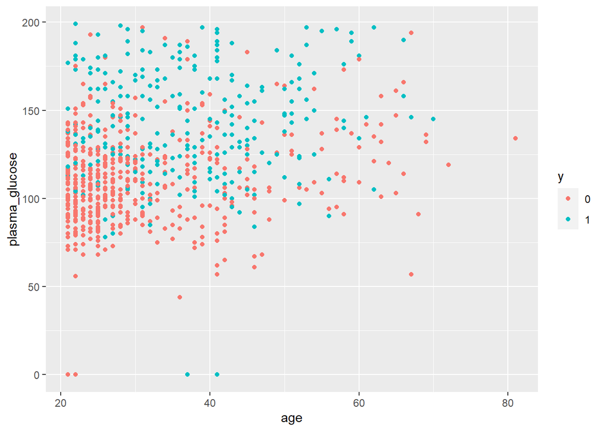

```r
dataset <- read.csv("./dataset/pima-indians-diabetes.csv", header = FALSE)
colnames(dataset)[c(2, 8, 9)] <- c("plasma_glucose", "age", "y")
dataset$y <- factor(dataset$y)
ggplot(dataset, aes(age, plasma_glucose, color = y)) + geom_point()
```

```r
glm_model <- glm(y~age + plasma_glucose, family = "binomial", data = dataset)
summary(glm_model)
```

```
##
## Call:
## glm(formula = y ~ age + plasma_glucose, family = "binomial",
##     data = dataset)
##
## Deviance Residuals:
##     Min       1Q   Median       3Q      Max
## -2.3367  -0.7775  -0.5087   0.8367   3.1630
##
## Coefficients:
##                 Estimate Std. Error z value Pr(>|z|)
## (Intercept)    -5.912449   0.462620  -12.78  < 2e-16 ***
## age             0.024778   0.007374    3.36 0.000778 ***
## plasma_glucose  0.035644   0.003290   10.83  < 2e-16 ***
## ---
## Signif. codes:  0 '***' 0.001 '**' 0.01 '*' 0.05 '.' 0.1 ' ' 1
##
## (Dispersion parameter for binomial family taken to be 1)
##
##     Null deviance: 993.48  on 767  degrees of freedom
## Residual deviance: 797.36  on 765  degrees of freedom
## AIC: 803.36
##
## Number of Fisher Scoring iterations: 4
```

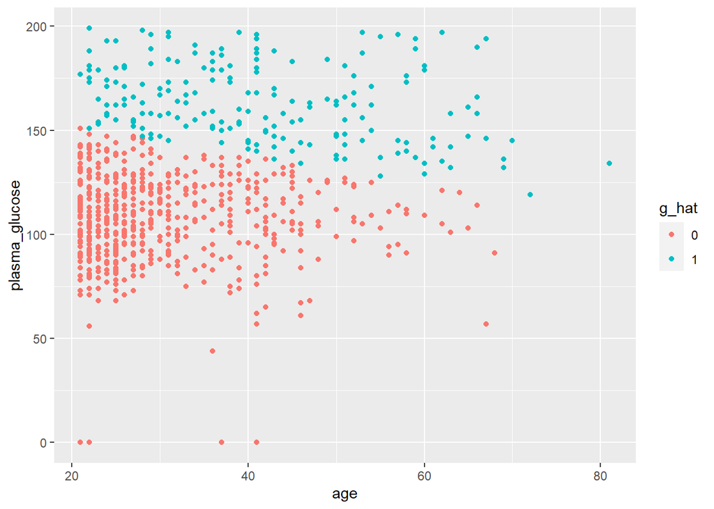

```r
dataset$g_hat <- ifelse(glm_model$fitted.values > 0.5, 1, 0) %>% as.factor()
ggplot(dataset, aes(age, plasma_glucose, color = g_hat)) + geom_point()
```

```r
cm <- table(dataset$y, dataset$g_hat)
1- (sum(diag(cm)) / nrow(dataset))
```

```
## [1] 0.2630208
```

### 2

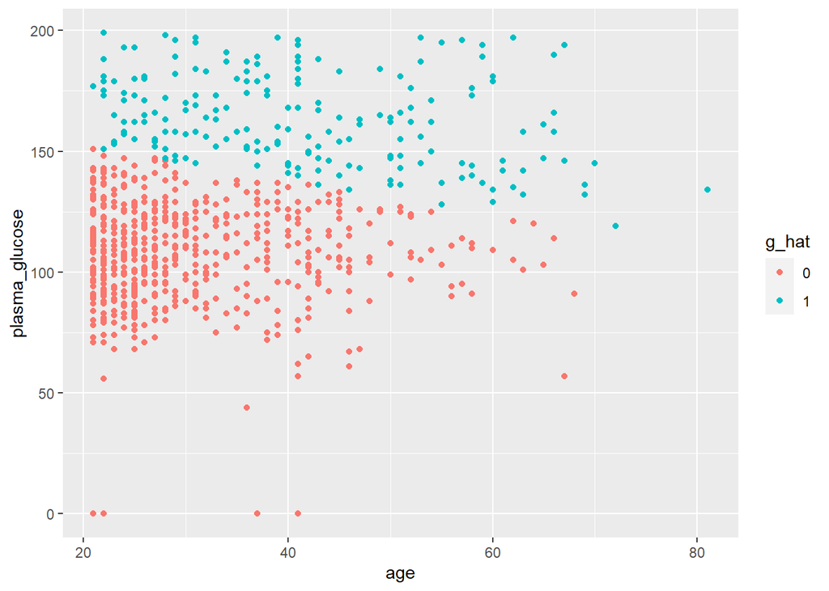

```r
slope <- coef(glm_model)[2] / -coef(glm_model)[3]
intercept <- coef(glm_model)[1] / -coef(glm_model)[3]
dataset$g_hat <- ifelse(glm_model$fitted.values > 0.5, 1, 0) %>% as.factor()
ggplot(dataset, aes(age, plasma_glucose, color = g_hat)) + geom_point()
```

```r
cm <- table(dataset$y, dataset$g_hat)
1- (sum(diag(cm)) / nrow(dataset))
```

```
## [1] 0.2630208
```

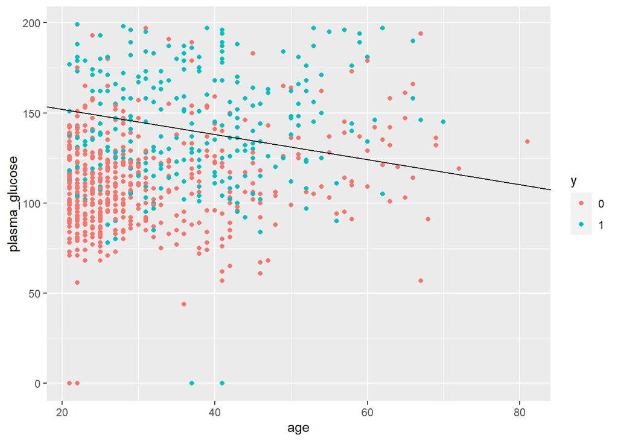

```r
ggplot(dataset, aes(age, plasma_glucose, color = y)) + geom_point()+
  geom_abline(aes(intercept = intercept, slope = slope))
```

### 3

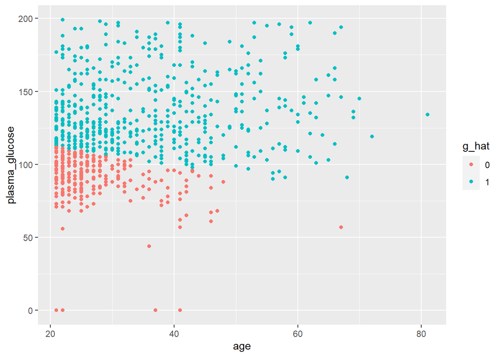

```r
dataset$g_hat <- ifelse(glm_model$fitted.values > 0.2, 1, 0) %>% as.factor()
ggplot(dataset, aes(age, plasma_glucose, color = g_hat)) + geom_point()
```

```r
cm <- table(dataset$y, dataset$g_hat)
1- (sum(diag(cm)) / nrow(dataset))
```

```
## [1] 0.3723958
```

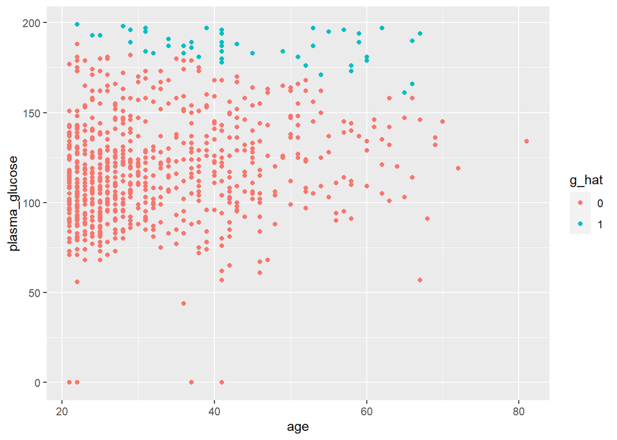

```r
dataset$g_hat <- ifelse(glm_model$fitted.values > 0.8, 1, 0) %>% as.factor()
ggplot(dataset, aes(age, plasma_glucose, color = g_hat)) + geom_point()
```

```r
cm <- table(dataset$y, dataset$g_hat)
1- (sum(diag(cm)) / nrow(dataset))
```

```
## [1] 0.3151042
```

### 4

```r
dataset <- dataset %>%
  mutate(z1= plasma_glucose^4, z2 = plasma_glucose^3 * age, z3 = plasma_glucose^2 * age^2, z4 = plasma_glucose * age^3, z4 = age^4)

glm_model <- glm(y~age + plasma_glucose + z1 + z2 + z3 + z4, family = "binomial", data = dataset)
summary(glm_model)
```

```
##
## Call:
## glm(formula = y ~ age + plasma_glucose + z1 + z2 + z3 + z4, family = "binomial",
##     data = dataset)
##
## Deviance Residuals:
##     Min       1Q   Median       3Q      Max
## -2.3767  -0.7401  -0.4366   0.7700   2.7795
##
## Coefficients:
##                  Estimate Std. Error z value Pr(>|z|)
## (Intercept)    -8.639e+00  1.111e+00  -7.778 7.39e-15 ***
## age             1.453e-01  2.040e-02   7.120 1.08e-12 ***
## plasma_glucose  3.071e-02  9.445e-03   3.252  0.00115 **
## z1              1.076e-09  3.046e-09   0.353  0.72406
## z2              5.816e-10  3.069e-08   0.019  0.98488
## z3             -1.674e-08  8.084e-08  -0.207  0.83590
## z4             -3.081e-07  1.478e-07  -2.085  0.03710 *
## ---
## Signif. codes:  0 '***' 0.001 '**' 0.01 '*' 0.05 '.' 0.1 ' ' 1
##
## (Dispersion parameter for binomial family taken to be 1)
##
##     Null deviance: 993.48  on 767  degrees of freedom
## Residual deviance: 748.12  on 761  degrees of freedom
## AIC: 762.12
##
## Number of Fisher Scoring iterations: 5
```

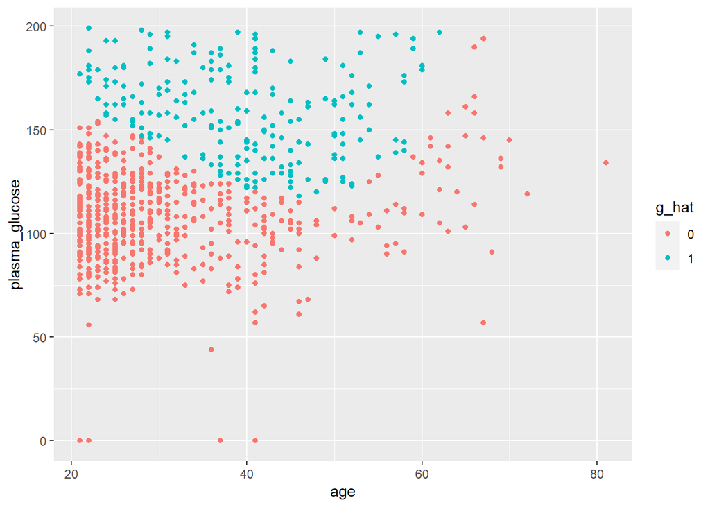

```r
dataset$g_hat <- ifelse(glm_model$fitted.values > 0.5, 1, 0) %>% as.factor()
ggplot(dataset, aes(age, plasma_glucose, color = g_hat)) + geom_point()
```

```r
cm <- table(dataset$y, dataset$g_hat)
1- (sum(diag(cm)) / nrow(dataset))
```

```
## [1] 0.2421875
```